# Horseshoe Prior

## Introduction

There are times when we have too many predictor variables to fit in our regression models not to be reasonably worried about spurious results. In this kind of of complex models, some sort of dimensionality reduction is indispensable, and a common way to achieve this is through shrinkage priors (Carvalho, Polson & Scott, 2009). **The Horseshoe Prior** is a useful tool in these cases. While it provides the prior with flat, Cauchy-like tails that allow for strong predictors to exert the right effect on $y$, it possesses an infinitely tall spike at the origin, endowing the zero elements of $\beta$ with severe shrinkage (Fig 1; Carvalho et al., 2009); this helps prevent spurious effects from the many predictors.

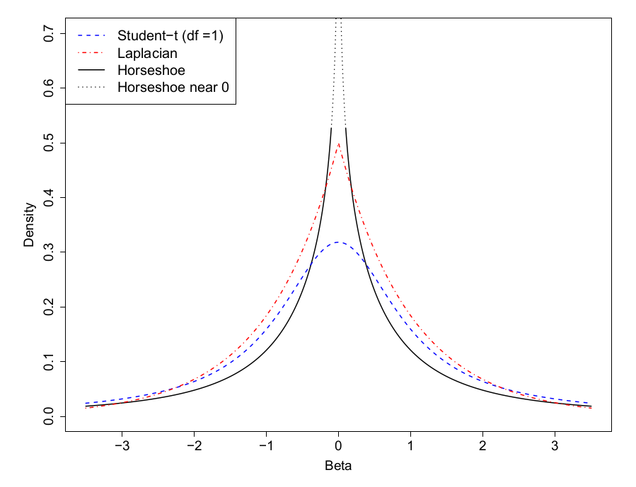

Fig. 1 (from Carvalho et al., 2009)

Here I provide an example of how to use horseshoe priors in bayesian models with {brms}.

## Preliminaries

### Load libraries

```r
library(tidyverse)
library(brms)
```

```r
scale_this <- function(x){
  (x - mean(x, na.rm=TRUE)) / sd(x, na.rm=TRUE)
}
```

### Simulate data

Here we simulate brain volume data based on estimates from Reite et al. (2010)

```r
set.seed(404)
sd <- 150

df <- tibble(
  brain_volume = rnorm(200, mean = 1200, sd = 150),
  age          = round(runif(200, min = 40, max = 70), digits = 0),
  sex          = factor(sample(c('male', 'female'), size = 200, replace = TRUE)),
  does_sport   = factor(sample(c('yes', 'no'), size = 200, replace = TRUE)),
  n_children   = sample(c(0,1,2,3,4), prob = c(.3, .4, .2, .08, .02), size = 200, replace = TRUE),
  sleep_hrs    = round(rnorm(200, mean = 8, sd = 1), digits = 1),
  vegetarian   = factor(sample(c('yes', 'no'), size = 200, replace = TRUE, prob = c(.1, .9))),
  education    = sample(c(12, 16, 19, 9, 6), prob = c(.68, .2, .05, .05, .2), replace = TRUE, size = 200),
  pets         = sample(c(0, 1, 2, 3), prob = c(.2, .4, .3, .1), size = 200, replace = TRUE),
  unemployed   = factor(sample(c('yes', 'no'), prob = c(.2, .8), size = 200, replace = TRUE)),
  drinks_week  = sample(0:12, size = 200, replace = TRUE),
  smoke_day    = sample(0:10, size = 200, replace = TRUE),
  instrument   = factor(sample(c('yes', 'no'), size = 200, replace = TRUE)),
  weight       = round(rnorm(200, mean = 80, sd = 10), digits = 1),
  height       = round(rnorm(200, mean = 165, sd = 10), digits = 1),
  hrs_seated   = round(rnorm(200, mean = 5, sd = 1), digits = 1),
  test_score   = round(rnorm(200, mean = 90, sd = 20), digits = 0),
  chr_depression= factor(sample(c('yes', 'no'), size = 200, replace = TRUE))
)

df <- df %>%
  mutate(
    brain_volume = case_when(
     age > 60            ~ brain_volume - 100 * sample(0:3, size = 1),
     age > 50 & age < 61 ~ brain_volume - 50  * sample(0:3, size = 1),
     TRUE                ~ brain_volume - 50  * sample(-2:2, size = 1)
    ),
    brain_volume = ifelse(sex == 'male',
                          brain_volume + 60 * sample(0:1, size = 1),
                          brain_volume - 60 * sample(0:1, size = 1)),
    brain_volume = ifelse(chr_depression == 'yes', brain_volume - 100 * sample(1:4), brain_volume),
    brain_volume = ifelse(sleep_hrs > 8, brain_volume + 100 * sample(0:2, size = 1), brain_volume)
  )
```

Such that now we have these data:

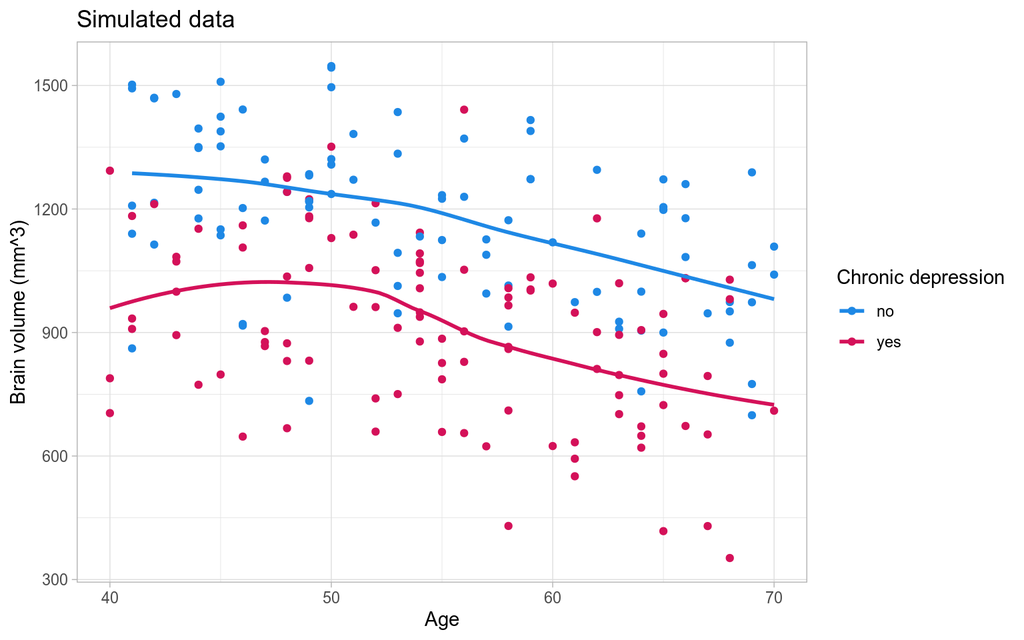

```r
df %>%
  ggplot(aes(x = age, y = brain_volume, color = chr_depression)) +
  geom_point() +
  geom_smooth(se = FALSE) +
  labs(x = "Age", y  = "Brain volume (mm^3)", color = "Chronic depression",
       title = "Simulated data") +
  theme_light() +
  scale_color_manual(values = c("#1E88E5", "#D41159")) # colorblind friendly
```

Before beginning, we want to scale the continuous predictors:

```r
df <- df %>%
  mutate(age = scale_this(age),
         sleep_hrs = scale_this(sleep_hrs),
         education = scale_this(education),
         n_children = scale_this(n_children),
         pets = scale_this(pets),
         drinks_week = scale_this(drinks_week),
         smoke_day = scale_this(smoke_day),
         weight = scale_this(weight),
         height = scale_this(height),
         hrs_seated = scale_this(hrs_seated),
         test_score = scale_this(test_score))
```

## Fit models

Now let’s fit some bayesian models. First we will fit a naive model (i.e. that does not account for spurious effects) and one with horseshoe prior.

### Naive model

```r
naive <- brm(brain_volume ~ chr_depression * does_sport + age + sex + n_children + unemployed + sleep_hrs + vegetarian +
             education + pets + drinks_week + smoke_day + instrument + weight * height + hrs_seated + test_score,
             family = "gaussian", data = df,
             prior = c(prior(normal(1200, 100), class = Intercept),
                        prior(normal(0, 100), class = b),
                        prior(exponential(1), class = sigma)),
             chains = 4, cores = 4, iter = 1000, warmup = 500, file = "models/vign_4.brm",
             seed = 404)

posterior_summary(naive)
```

```
                                       Estimate Est.Error          Q2.5
b_Intercept                        1175.2775919 23.591303  1128.2417731
b_chr_depressionyes                -228.1870957 24.855512  -277.4199051
b_does_sportyes                      48.8776406 24.826730     0.1667996
b_age                              -101.3480535  9.318712  -119.9126523
b_sexmale                           -21.3825377 17.872815   -56.5960096
b_n_children                         -5.7668680  9.409525   -24.0627615
b_unemployedyes                     -27.7671813 23.968977   -75.3073767
b_sleep_hrs                          95.5729942  9.133960    77.4511401
b_vegetarianyes                     -32.4070915 31.352288   -94.7607498
b_education                          20.0053052  9.311767     1.2732655
b_pets                                0.2215192  9.317841   -18.2364109
b_drinks_week                        -0.7112459  8.927870   -19.1358592
b_smoke_day                          -4.0509162  9.204344   -22.2499720
b_instrumentyes                      -8.5067432 18.806602   -45.9698038
b_weight                             -6.5742571  9.552312   -25.7901196
b_height                              5.4276450  9.168771   -12.0392594
b_hrs_seated                        -17.6334457  9.109250   -35.3379704
b_test_score                         -3.1500861  9.419868   -21.7437262
                                          Q97.5
b_Intercept                        1.221170e+03
b_chr_depressionyes               -1.799347e+02
b_does_sportyes                    9.891195e+01
b_age                             -8.300283e+01
b_sexmale                          1.430727e+01
b_n_children                       1.282712e+01
b_unemployedyes                    1.967924e+01
b_sleep_hrs                        1.135719e+02
b_vegetarianyes                    3.009211e+01
b_education                        3.801008e+01
b_pets                             1.830797e+01
b_drinks_week                      1.563617e+01
b_smoke_day                        1.397401e+01
b_instrumentyes                    2.692687e+01
b_weight                           1.176860e+01
b_height                           2.402595e+01
b_hrs_seated                       9.101546e-02
b_test_score                       1.539594e+01
 [ reached getOption("max.print") -- omitted 4 rows ]
```

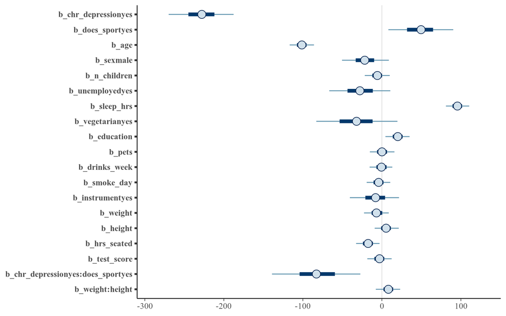

```r
mcmc_plot(naive, variable = variables(naive)[2:20])
```

We find the expected variables with a strong effect, but also at least two more: *education* and *hours sitting per day*. Since we simulated the data, we know these effects are spurious. Let’s see what happens when we use a horseshoe prior.

### Horseshoe prior model

```r
horse <- brm(brain_volume ~ chr_depression * does_sport + age + sex + n_children + unemployed + sleep_hrs + vegetarian +
             education + pets + drinks_week + smoke_day + instrument + weight * height + hrs_seated + test_score,
             family = "gaussian", data = df,
             prior = c(prior(normal(1200, 100), class = Intercept),
                       prior(horseshoe(1), class = b), # the argument in the horseshoe function is usually set to 1 for optimal results
                       prior(exponential(1), class = sigma)),
             chains = 4, cores = 4, iter = 1000, warmup = 500, file = "models/vign_5.brm",
             seed = 404)

posterior_summary(horse)
```

```
                                       Estimate Est.Error         Q2.5
b_Intercept                        1.177407e+03 18.399900  1140.813809
b_chr_depressionyes               -2.550429e+02 23.714399  -297.421080
b_does_sportyes                    8.968376e+00 17.268323   -13.516283
b_age                             -9.909372e+01  9.229726  -116.769758
b_sexmale                         -7.312070e+00 12.774319   -38.308658
b_n_children                      -2.132708e+00  6.318928   -16.966711
b_unemployedyes                   -9.059682e+00 16.707989   -53.330201
b_sleep_hrs                        9.163297e+01  9.594173    72.569098
b_vegetarianyes                   -5.277670e+00 16.884516   -50.109321
b_education                        9.499687e+00  9.026107    -3.451229
b_pets                            -1.914863e-02  5.878993   -12.653540
b_drinks_week                     -3.578334e-02  6.018267   -13.584618
b_smoke_day                       -1.579372e+00  6.207673   -15.920520
b_instrumentyes                   -1.830194e+00 10.299150   -25.674571
b_weight                          -1.749353e+00  6.433334   -16.739606
b_height                           1.273213e+00  6.034950   -11.029553
b_hrs_seated                      -1.152808e+01  9.575306   -32.469594
b_test_score                      -1.837241e+00  6.288914   -17.157354
                                         Q97.5
b_Intercept                        1212.838245
b_chr_depressionyes                -206.140208
b_does_sportyes                      56.695431
b_age                               -81.191298
b_sexmale                            12.265461
b_n_children                          9.735355
b_unemployedyes                      13.652903
b_sleep_hrs                         110.147009
b_vegetarianyes                      25.149048
b_education                          29.037733
b_pets                               12.767139
b_drinks_week                        12.697427
b_smoke_day                          10.076581
b_instrumentyes                      18.414650
b_weight                             10.103026
b_height                             14.817157
b_hrs_seated                          2.483140
b_test_score                         10.191892
 [ reached getOption("max.print") -- omitted 4 rows ]
```

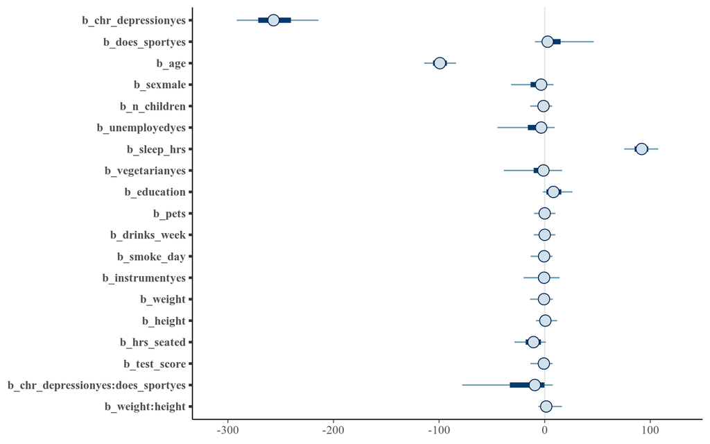

```r
mcmc_plot(horse, variable = variables(horse)[2:20])
```

The spurious effects disappear thanks to our horseshoe prior and its elicited shrinkage towards 0!

### Model comparison

To confirm that the horseshoe prior model is indeed better than the naive one, we can compare the models using *loo_compare*.

```r
naive <- add_criterion(naive, criterion = "loo")
horse <- add_criterion(horse, criterion = "loo")

comparison <- loo_compare(naive, horse, criterion = "loo")

print(comparison, simplify = F)
```

```
      elpd_diff se_diff elpd_loo se_elpd_loo p_loo   se_p_loo looic   se_looic
horse     0.0       0.0 -1327.4     15.0        21.7     2.2   2654.9    30.0
naive    -6.1       3.6 -1333.5     14.9        32.3     3.2   2667.0    29.9
```

In sum, it seems that the horseshoe prior is a useful tool to be able to include many predictor variables in our bayesian models while greatly reducing the risk of getting false positive-like effects. Consult the references and the {brms} manual for further information.

## References

- Carvalho, Carlos & Polson, Nicholas & Scott, James. (2009). Handling Sparsity via the Horseshoe.. Journal of Machine Learning Research - Proceedings Track. 5. 73-80.
- Reite et al.: Brain size and brain/intracranial volume ratio in major mental illness. BMC Psychiatry 2010 10:79.